# Time Series Modelling

### Inferences from a Time Series Model, estimate a linear trend model and Include seasonal effects. Make predictions using the model developed.

```r
rm(list = ls())
cat("\f")
```

```r
rm(list = ls())
cat("\f")
```

```r
# Install packages if you have never installed them.
# install.packages("xlsx")
# install.packages("rJava")
# install.packages("tseries")
# install.packages("forecast")

#Loading packages
library(tseries)
library(rJava)
library(xlsx)
library(lubridate)
```

```r
datas1 = read.xlsx('Keeling_CO2data_2017.xlsx',1,rowIndex = 8:713,colIndex = 1:5);
colnames(datas1) <- c("Yr","month","Date1","Date2","CO2.ppm")
# datas1 <- datas1[12:nrow(datas1),]

datas1$Yr <- ifelse(datas1$month == 12,datas1$Yr-1,datas1$Yr )

datas1$datenew <- mdy(paste(datas1$month,'01',datas1$Yr,sep = '-'))
datas1 <- datas1[,c(5:6)]
datas1$month <- as.factor(month(datas1$datenew))
datas1$month <- factor(datas1$month, levels=unique(datas1$month))
```

## CO2 PPM Rate

## Part 1

Plot the CO2 time series in column E. Briefly summarize the evidence of seasonal effects and trends in the time-series plot.

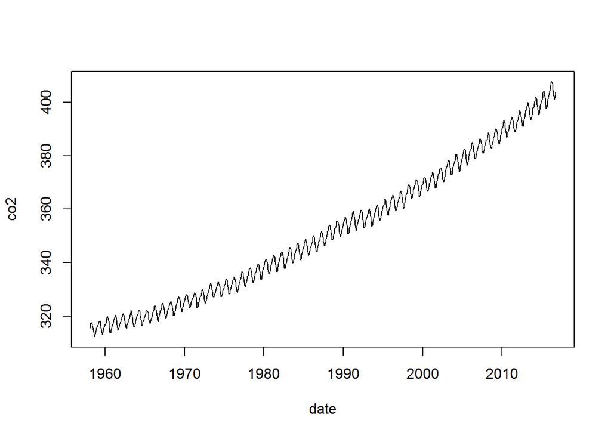

```r
# Plot raw data
plot(datas1$datenew, datas1$CO2.ppm, xlab = 'date', ylab = 'co2', type='l')
```

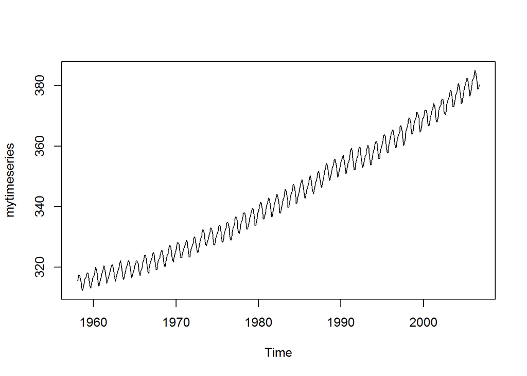

```r
mytimeseries = ts(data = datas1$CO2.ppm, start=c(1958, 2), end=c(2006, 10), frequency = 12)
plot(mytimeseries)
```

```r
class(mytimeseries)
```

```
## [1] "ts"
```

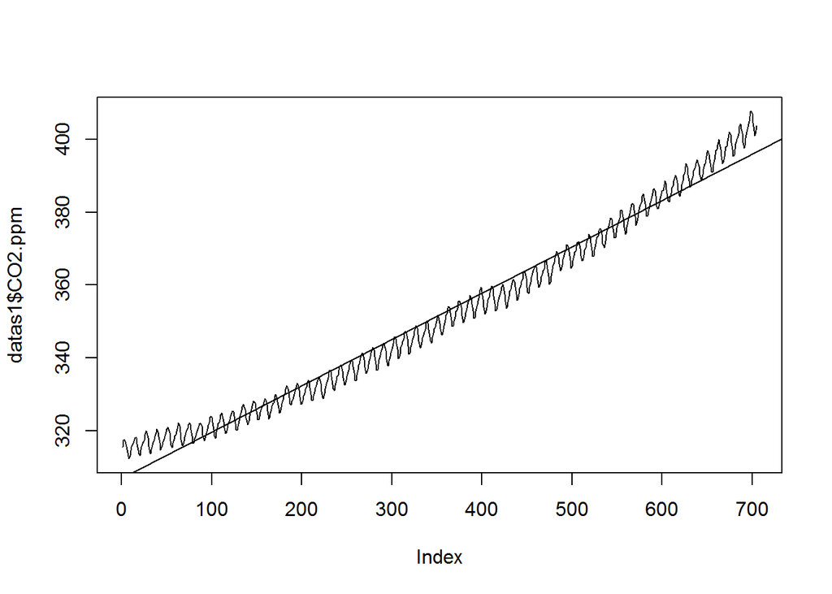

```r
plot(datas1$CO2.ppm, type='l')
abline(reg=lm(datas1$CO2.ppm~time(datas1$CO2.ppm)))
```

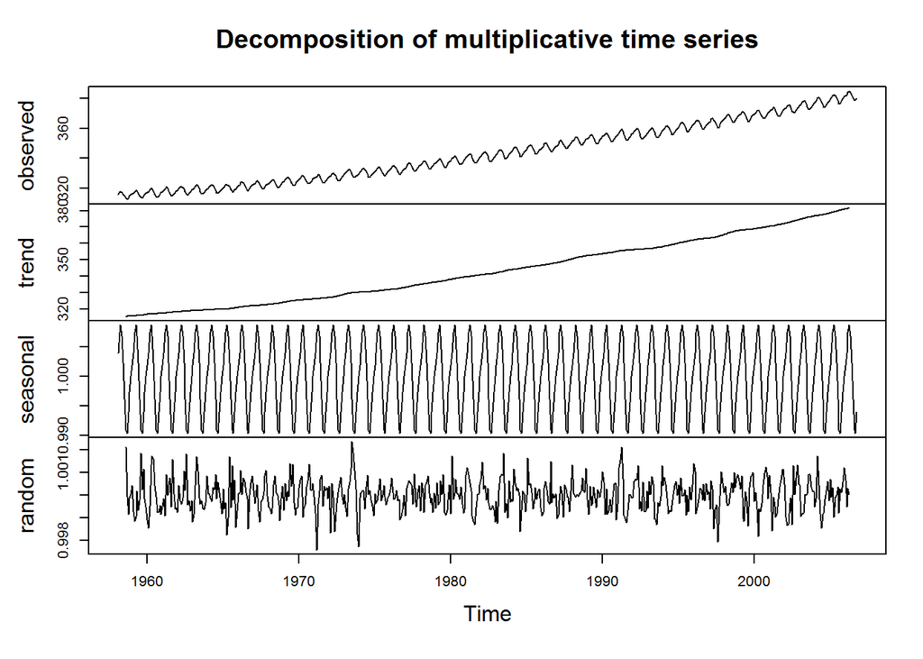

```r
# decompose(mytimeseries, "multiplicative") # decompose is in R base
plot(decompose(mytimeseries, type = "multiplicative"))
```

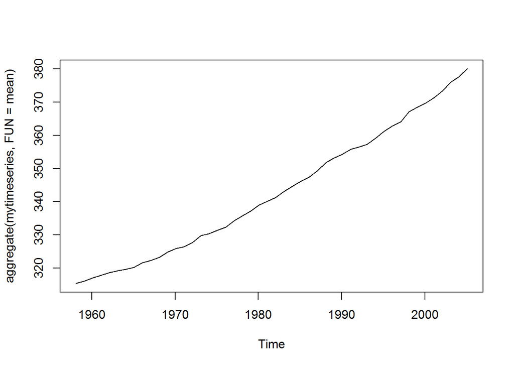

```r
plot(aggregate(mytimeseries,FUN=mean))
```

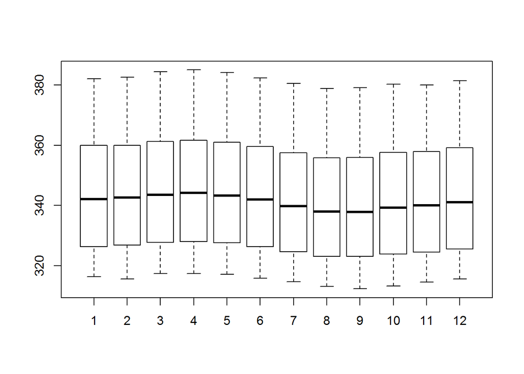

```r
#Box plot across months will give us a sense on seasonal effect
boxplot(mytimeseries~cycle(mytimeseries))
```

## Part 2

Using data up to 2005, estimate a linear trend model for the CO2 measurements. Is the trend significant? Is the linear trend a good specification that yields reliable forecasts?

```r
datas1.2005 <- datas1[datas1$datenew<= '2005-12-01',]
datas1.2005$month <- factor(datas1.2005$month, levels=unique(datas1.2005$month))
str(datas1.2005)
```

```
## 'data.frame':    575 obs. of  3 variables:
##  $ CO2.ppm: num  316 317 318 317 316 ...
##  $ datenew: Date, format: "1958-02-01" "1958-03-01" "1958-04-01" "1958-05-01" ...
##  $ month  : Factor w/ 12 levels "2","3","4","5",..: 1 2 3 4 5 6 7 8 9 10 ...
```

```r
reg=lm(datas1.2005$CO2.ppm~time(datas1.2005$CO2.ppm))
summary(reg)
```

```
##
## Call:
## lm(formula = datas1.2005$CO2.ppm ~ time(datas1.2005$CO2.ppm))
##
## Residuals:
##     Min      1Q  Median      3Q     Max
## -6.4895 -2.1069  0.0112  1.9566  7.6063
##
## Coefficients:
##                              Estimate  Std. Error t value            Pr(>|t|)
## (Intercept)               309.6131947   0.2489210  1243.8 <0.0000000000000002 ***
## time(datas1.2005$CO2.ppm)   0.1152515   0.0007488   153.9 <0.0000000000000002 ***
## ---
## Signif. codes:  0 '***' 0.001 '**' 0.01 '*' 0.05 '.' 0.1 ' ' 1
##
## Residual standard error: 2.981 on 573 degrees of freedom
## Multiple R-squared:  0.9764, Adjusted R-squared:  0.9763
## F-statistic: 2.369e+04 on 1 and 573 DF,  p-value: < 0.00000000000000022
```

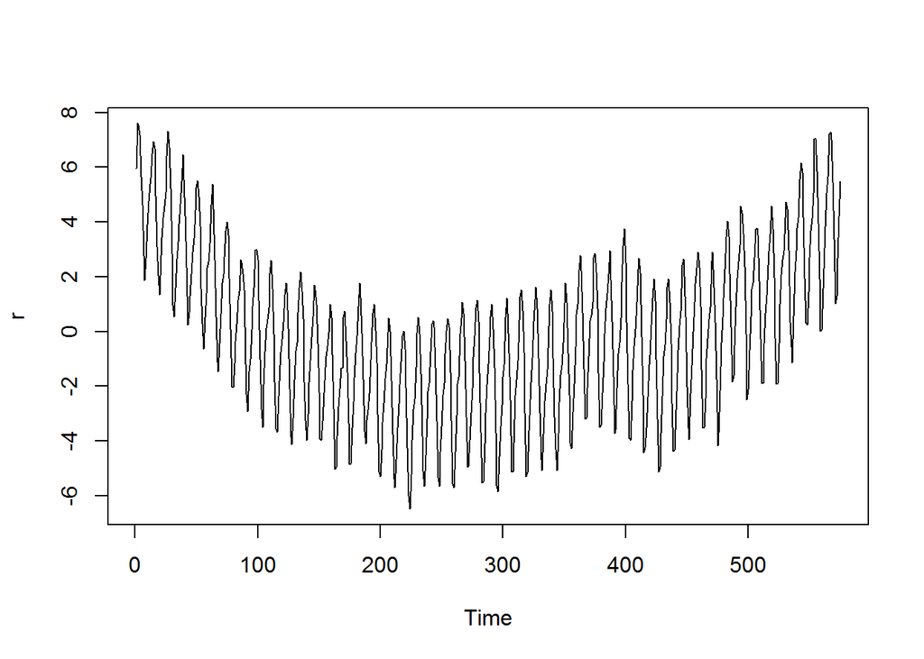

```r
r <- reg$residuals # get the residuals from the fit
plot.ts(r)
```

```r
Box.test(reg$residuals)
```

```
##
##  Box-Pierce test
##
## data:  reg$residuals
## X-squared = 476.03, df = 1, p-value < 0.00000000000000022
```

Solution 2-

Yes the trend is significant . Looking at the statistical significance of the intercepts andcoefficient , we can say that there is a positive trend(Coefficient estimate for the time stamp is postive)of CO2 PPM level over time.However there is a clear trend in the residuals plot as it tends to have non constant variance and is heteroscedastic; so this is clearly not the best model and there is scope of improvement to make the model better, we can include inverse/squared terms in our regression and check if we get a model with no/little trend in the residuals.

## Part 3

Using data up to 2005, develop a better trend specification. Report your trend estimates and explain what your specification is and what makes it better.

```r
datas1.2005$CO2.ppm.sq <- datas1.2005$CO2.ppm^2
datas1.2005$CO2.ppm.in <- 1/datas1.2005$CO2.ppm^2
datas1.2005$CO2.ppm.cube <- datas1.2005$CO2.ppm^3
datas1.2005$time <- I(1:length(datas1.2005$CO2.ppm))
datas1.2005$time.sq <- I(datas1.2005$time^2)
datas1.2005$time.cube <- I(datas1.2005$time^3)

str(datas1.2005)
```

```
## 'data.frame':    575 obs. of  9 variables:
##  $ CO2.ppm     : num  316 317 318 317 316 ...
##  $ datenew     : Date, format: "1958-02-01" "1958-03-01" "1958-04-01" "1958-05-01" ...
##  $ month       : Factor w/ 12 levels "2","3","4","5",..: 1 2 3 4 5 6 7 8 9 10 ...
##  $ CO2.ppm.sq  : num  99666 100775 100806 100654 99768 ...
##  $ CO2.ppm.in  : num  0.00001003 0.00000992 0.00000992 0.00000994 0.00001002 ...
##  $ CO2.ppm.cube: num  31464711 31990866 32005984 31933459 31512575 ...
##  $ time        :Class 'AsIs'  int [1:575] 1 2 3 4 5 6 7 8 9 10 ...
##  $ time.sq     :Class 'AsIs'  num [1:575] 1 4 9 16 25 36 49 64 81 100 ...
##  $ time.cube   :Class 'AsIs'  num [1:575] 1 8 27 64 125 216 343 512 729 1000 ...
```

```r
reg2=lm(CO2.ppm.in~time, data=datas1.2005)
summary(reg2)
```

```
##
## Call:
## lm(formula = CO2.ppm.in ~ time, data = datas1.2005)
##
## Residuals:
##             Min              1Q          Median              3Q             Max
## -0.000000313049 -0.000000090084 -0.000000008257  0.000000086686  0.000000287383
##
## Coefficients:
##                      Estimate        Std. Error t value            Pr(>|t|)
## (Intercept)  0.00001023064843  0.00000000982610  1041.2 <0.0000000000000002 ***
## time        -0.00000000569650  0.00000000002956  -192.7 <0.0000000000000002 ***
## ---
## Signif. codes:  0 '***' 0.001 '**' 0.01 '*' 0.05 '.' 0.1 ' ' 1
##
## Residual standard error: 0.0000001177 on 573 degrees of freedom
## Multiple R-squared:  0.9848, Adjusted R-squared:  0.9848
## F-statistic: 3.714e+04 on 1 and 573 DF,  p-value: < 0.00000000000000022
```

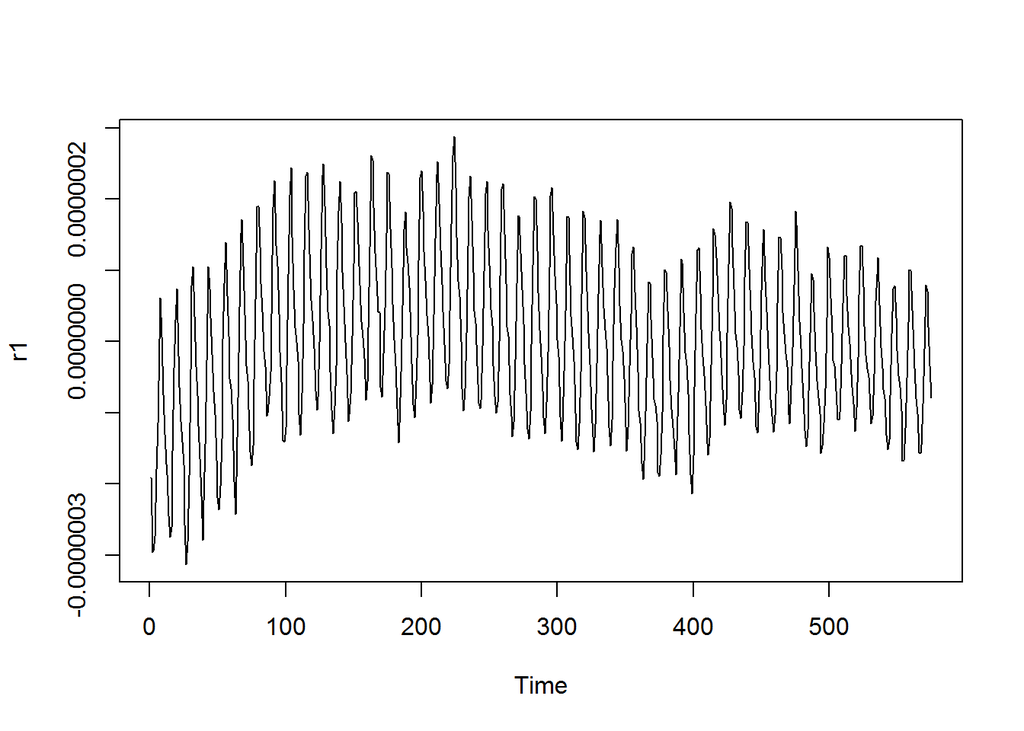

```r
r1 <- reg2$residuals
plot.ts(r1)
```

```r
Box.test(reg2$residuals)
```

```
##
##  Box-Pierce test
##
## data:  reg2$residuals
## X-squared = 425.81, df = 1, p-value < 0.00000000000000022
```

## Part 4

Include seasonal effects and report results for your preferred model that includes both trend and seasonal effects. Again, use data only up to 2005.

```r
reg3=lm(CO2.ppm.in~time+ month, data=datas1.2005)
summary(reg3)
```

```
##
## Call:
## lm(formula = CO2.ppm.in ~ time + month, data = datas1.2005)
##
## Residuals:
##             Min              1Q          Median              3Q             Max
## -0.000000179052 -0.000000033440  0.000000005392  0.000000039833  0.000000120723
##
## Coefficients:
##                      Estimate        Std. Error  t value             Pr(>|t|)
## (Intercept)  0.00001016335135  0.00000000897426 1132.500 < 0.0000000000000002 ***
## time        -0.00000000570430  0.00000000001401 -407.015 < 0.0000000000000002 ***
## month3      -0.00000005844447  0.00000001138477   -5.134     0.00000039238024 ***
## month4      -0.00000007960784  0.00000001138480   -6.992     0.00000000000769 ***
## month5      -0.00000004802884  0.00000001138484   -4.219     0.00002864601585 ***
## month6       0.00000002773311  0.00000001138490    2.436             0.015162 *
## month7       0.00000013251256  0.00000001138498   11.639 < 0.0000000000000002 ***
## month8       0.00000022570059  0.00000001138507   19.824 < 0.0000000000000002 ***
## month9       0.00000023570225  0.00000001138519   20.703 < 0.0000000000000002 ***
## month10      0.00000017352191  0.00000001138532   15.241 < 0.0000000000000002 ***
## month11      0.00000011570012  0.00000001138546   10.162 < 0.0000000000000002 ***
## month12      0.00000007011610  0.00000001138563    6.158     0.00000000140103 ***
## month1       0.00000003895373  0.00000001144538    3.403             0.000713 ***
## ---
## Signif. codes:  0 '***' 0.001 '**' 0.01 '*' 0.05 '.' 0.1 ' ' 1
##
## Residual standard error: 0.00000005577 on 562 degrees of freedom
## Multiple R-squared:  0.9967, Adjusted R-squared:  0.9966
## F-statistic: 1.394e+04 on 12 and 562 DF,  p-value: < 0.00000000000000022
```

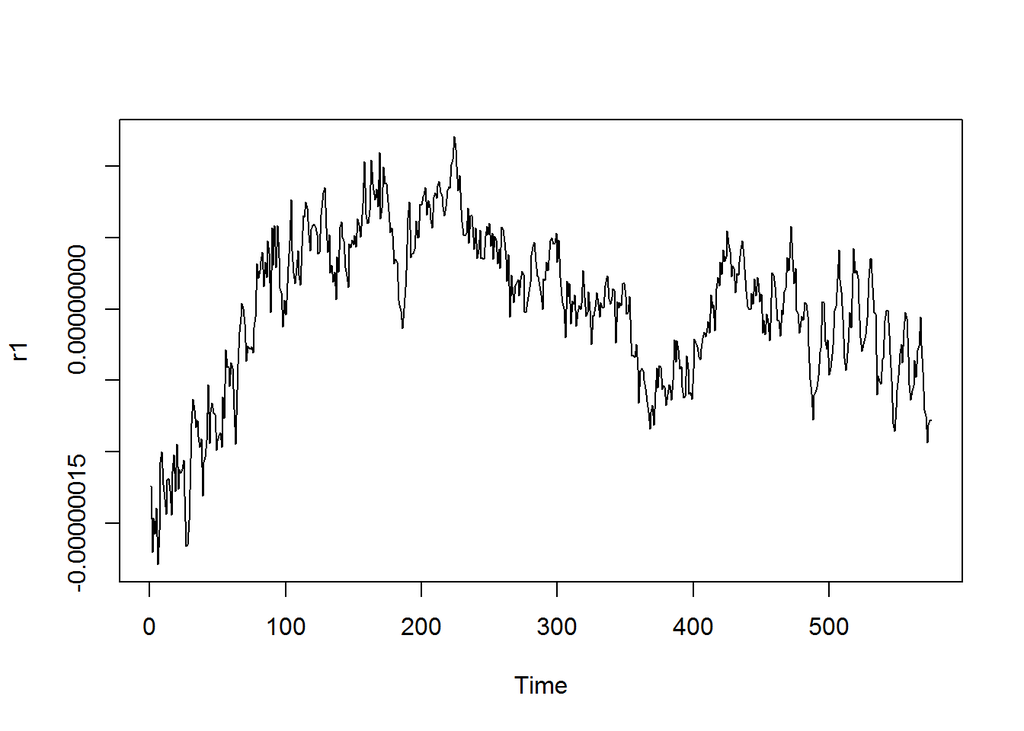

```r
r1 <- reg3$residuals
plot.ts(r1)
```

```r
Box.test(reg3$residuals)
```

```
##
##  Box-Pierce test
##
## data:  reg3$residuals
## X-squared = 518.71, df = 1, p-value < 0.00000000000000022
```

Results from this model indicate an increase in Adjusted R-Square to 99.66% from 98.48%

## Part 5

Using data up to 2005m12, forecast future CO2 for the period 2006m01 to 2016m10. Evaluate how good the forecasts from this model are. Are there any obvious problems with your forecasts [hint: are the forecast errors unpredictable]?

```r
str(datas1)
```

```
## 'data.frame':    705 obs. of  3 variables:
##  $ CO2.ppm: num  316 317 318 317 316 ...
##  $ datenew: Date, format: "1958-02-01" "1958-03-01" "1958-04-01" "1958-05-01" ...
##  $ month  : Factor w/ 12 levels "2","3","4","5",..: 1 2 3 4 5 6 7 8 9 10 ...
```

```r
datas1.2006 <- datas1[datas1$datenew > '2005-12-01',]
datas1.2006$month <- factor(datas1.2006$month, levels=unique(datas1.2006$month))
str(datas1.2006)
```

```
## 'data.frame':    130 obs. of  3 variables:
##  $ CO2.ppm: num  382 383 384 385 384 ...
##  $ datenew: Date, format: "2006-01-01" "2006-02-01" "2006-03-01" "2006-04-01" ...
##  $ month  : Factor w/ 12 levels "1","2","3","4",..: 1 2 3 4 5 6 7 8 9 10 ...
```

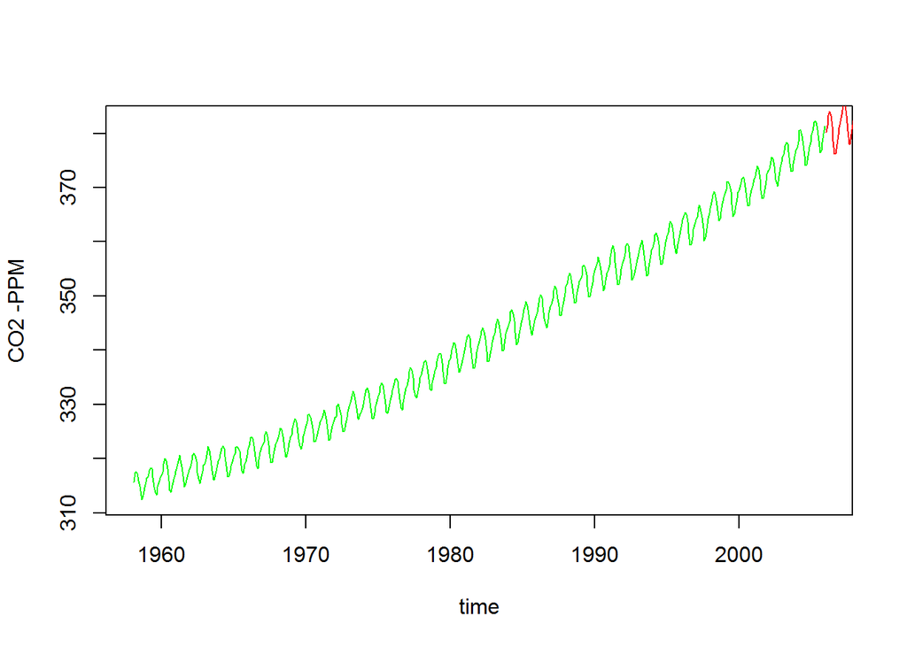

```r
datas1.2006$CO2.ppm.sq <- datas1.2006$CO2.ppm^2
datas1.2006$CO2.ppm.in <- 1/datas1.2006$CO2.ppm^2
datas1.2006$CO2.ppm.cube <- datas1.2006$CO2.ppm^3
datas1.2006$time <- c(1:length(datas1.2006$CO2.ppm))
datas1.2006$time <- datas1.2006$time+575
datas1.2006$time.sq <- I(datas1.2006$time^2)
datas1.2006$time.cube <- I(datas1.2006$time^3)

# datas1.2006 <- datas1.2006[,c("time","month")]
# length(datas1.2005$CO2.ppm)


# df <- as.data.frame(time(datas1.2005$CO2.ppm),datas1.2006$month)
# pred.val <- predict.lm(reg3,newdata = as.data.frame(time(datas1.2005$CO2.ppm),datas1.2006[,c("month")])

pred.val <- predict(reg3,newdata = datas1.2006[,c("time","month")])

plot(datas1.2005$datenew, 1/(datas1.2005$CO2.ppm.in)^0.5, xlab = 'time', ylab = 'CO2 -PPM', type='l',col='green')
lines(datas1.2006$datenew, 1/(pred.val)^0.5,col='red')
```

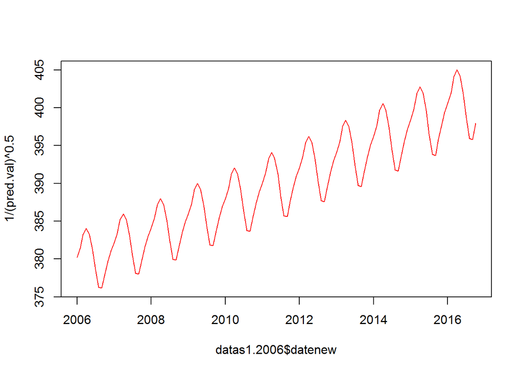

```r
plot(datas1.2006$datenew, 1/(pred.val)^0.5, col='red',type='l')
```

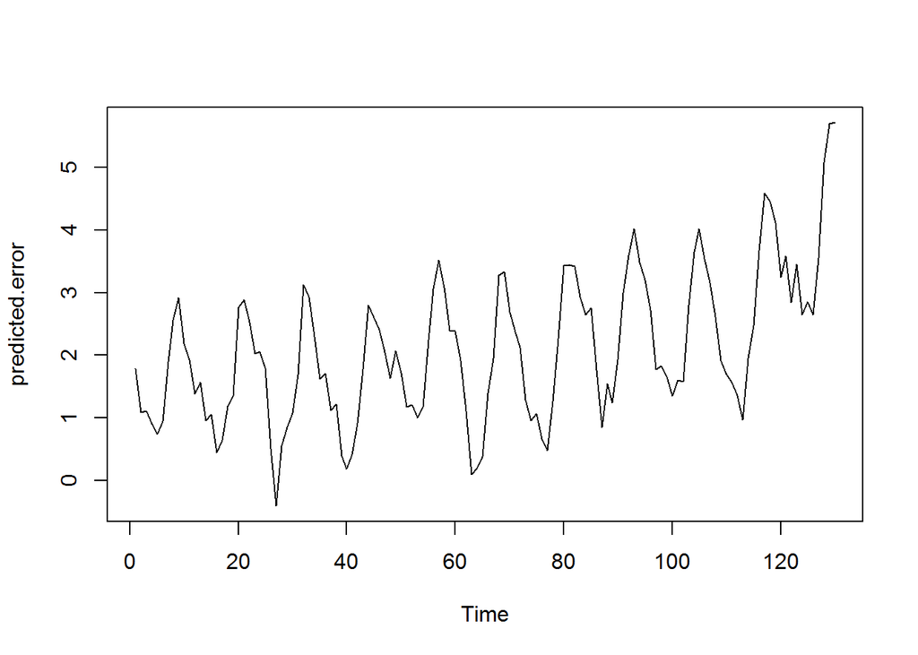

```r
predicted.error <- 1/(datas1.2006$CO2.ppm.in)^0.5- 1/(pred.val)^0.5
plot.ts(predicted.error)
```

the errors are almost constant .though it has in increasing trend towards the later part of the predicted months

```r
library(forecast)

accuracy(1/(datas1.2006$CO2.ppm.in)^0.5,1/(pred.val)^0.5)
```

```
##                 ME     RMSE     MAE        MPE      MAPE
## Test set -2.105442 2.405768 2.11167 -0.5392301 0.5408388
```

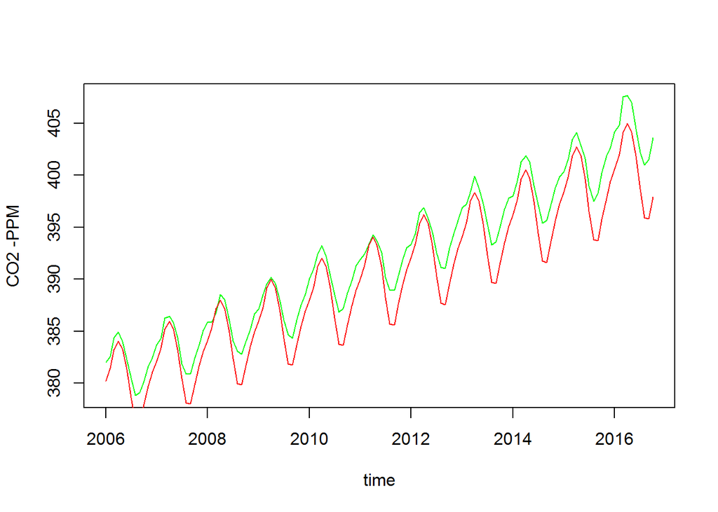

```r
plot(datas1.2006$datenew, 1/(datas1.2006$CO2.ppm.in)^0.5, xlab = 'time', ylab = 'CO2 -PPM', type='l',col='green')
lines(datas1.2006$datenew, 1/(pred.val)^0.5,col='red')
```

The predictions has been close for the most of the months and the RMSE for the predicted data is 2.4. The months that has low CO2 PPM has the highest deviation in prediction.

## Part 6

We believe that Population of Hawaai could be an important feature that could explain the variance in the data. Therefore we donwloaded the population data from this Source -

https://united-states.reaproject.org/analysis/comparative-trends-analysis/population/reports/150000/0/

```r
# browseURL("https://united-states.reaproject.org/analysis/comparative-trends-analysis/population/reports/150000/0/")
```

```r
library(tidyverse)
Hawaii_population = read.xlsx('Hawaai_Population.xlsx',1);
datas1.2006$Year <- year(datas1.2006$datenew)
datas1.2006.new <- datas1.2006 %>% left_join(Hawaii_population,by="Year")

datas1.2005$Year <- year(datas1.2005$datenew)
datas1.2005.new <- datas1.2005 %>% left_join(Hawaii_population,by="Year")

reg4=lm(CO2.ppm.in~time+ month + Population, data=datas1.2005.new)
summary(reg4)
```

```
##
## Call:
## lm(formula = CO2.ppm.in ~ time + month + Population, data = datas1.2005.new)
##
## Residuals:
##             Min              1Q          Median              3Q             Max
## -0.000000178230 -0.000000031637  0.000000006083  0.000000039856  0.000000119874
##
## Coefficients:
##                        Estimate          Std. Error t value             Pr(>|t|)
## (Intercept)  0.0000100953115078  0.0000000659283719 153.125 < 0.0000000000000002 ***
## time        -0.0000000058446633  0.0000000001354715 -43.143 < 0.0000000000000002 ***
## month3      -0.0000000583041080  0.0000000113847074  -5.121     0.00000041786949 ***
## month4      -0.0000000793271026  0.0000000113871252  -6.966     0.00000000000914 ***
## month5      -0.0000000476077439  0.0000000113911537  -4.179     0.00003390379786 ***
## month6       0.0000000282945762  0.0000000113967912   2.483             0.013331 *
## month7       0.0000001332143943  0.0000000114040354  11.681 < 0.0000000000000002 ***
## month8       0.0000002265427847  0.0000000114128831  19.850 < 0.0000000000000002 ***
## month9       0.0000002366848139  0.0000000114233307  20.719 < 0.0000000000000002 ***
## month10      0.0000001746448452  0.0000000114353737  15.272 < 0.0000000000000002 ***
## month11      0.0000001169634145  0.0000000114490072  10.216 < 0.0000000000000002 ***
## month12      0.0000000715197694  0.0000000114642253   6.239     0.00000000087062 ***
## month1       0.0000000387958663  0.0000000114455117   3.390             0.000749 ***
## Population   0.0000000000001113  0.0000000000001069   1.042             0.297990
## ---
## Signif. codes:  0 '***' 0.001 '**' 0.01 '*' 0.05 '.' 0.1 ' ' 1
##
## Residual standard error: 0.00000005577 on 561 degrees of freedom
## Multiple R-squared:  0.9967, Adjusted R-squared:  0.9966
## F-statistic: 1.287e+04 on 13 and 561 DF,  p-value: < 0.00000000000000022
```

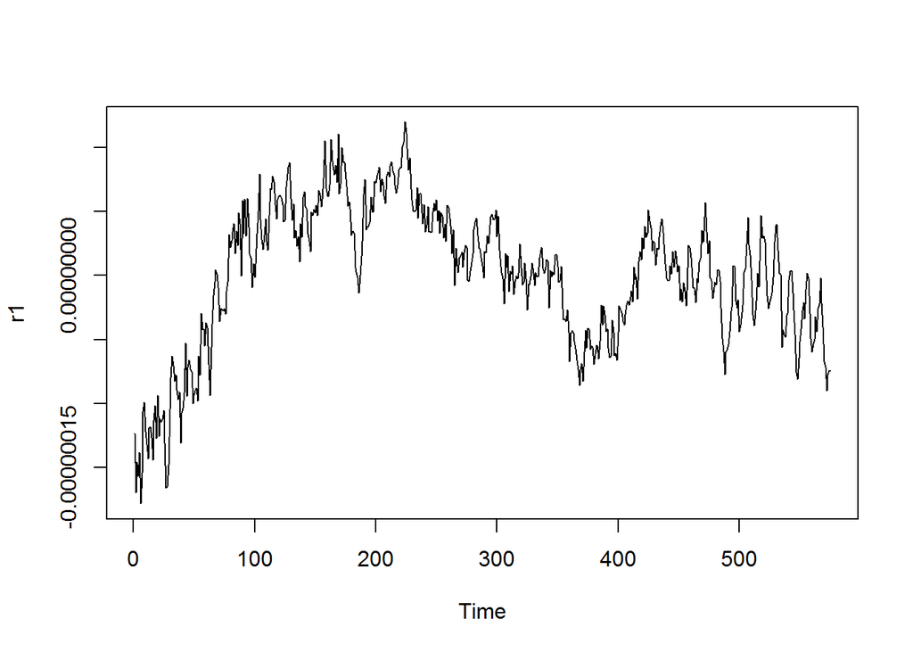

```r
r1 <- reg4$residuals
plot.ts(r1)
```

```r
Box.test(reg4$residuals)
```

```
##
##  Box-Pierce test
##
## data:  reg4$residuals
## X-squared = 518.8, df = 1, p-value < 0.00000000000000022
```

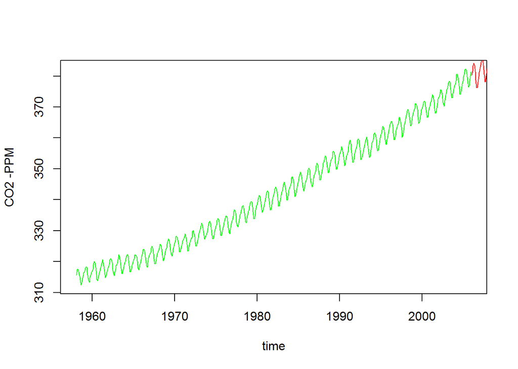

```r
pred.val.new <- predict(reg4,newdata = datas1.2006.new[,c("CO2.ppm.in","time","month","Population")])

plot(datas1.2005.new$datenew, 1/(datas1.2005.new$CO2.ppm.in)^0.5, xlab = 'time', ylab = 'CO2 -PPM', type='l',col='green')
lines(datas1.2006.new$datenew, 1/(pred.val.new)^0.5,col='red')
```

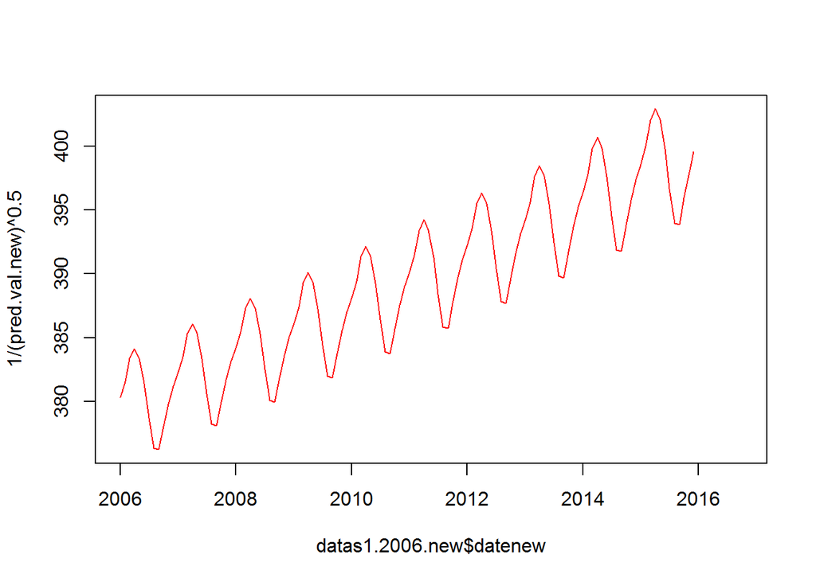

```r
plot(datas1.2006.new$datenew, 1/(pred.val.new)^0.5, col='red',type='l')
```

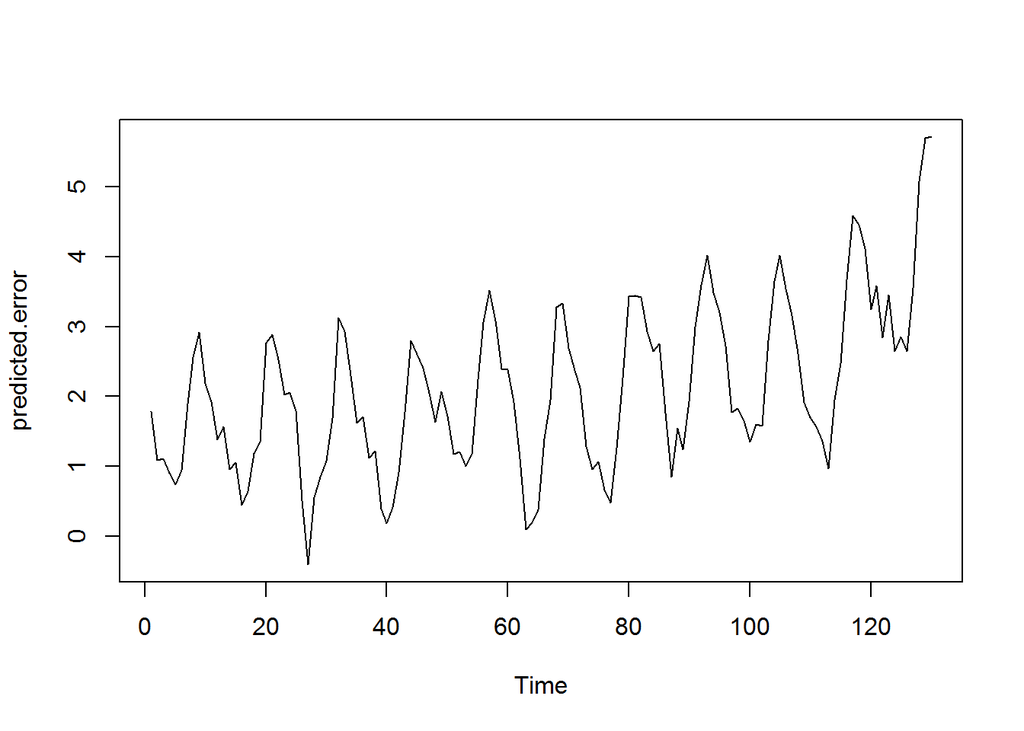

```r
predicted.error <- 1/(datas1.2006.new$CO2.ppm.in)^0.5- 1/(pred.val)^0.5
plot.ts(predicted.error)
```

the errors are almost constant .though it has in increasing trend towards the later part of the predicted months

```r
library(forecast)
accuracy(1/(datas1.2006$CO2.ppm.in)^0.5,1/(pred.val)^0.5)
```

```
##                 ME     RMSE     MAE        MPE      MAPE
## Test set -2.105442 2.405768 2.11167 -0.5392301 0.5408388
```

```r
accuracy(1/(datas1.2006.new$CO2.ppm.in)^0.5,1/(pred.val.new)^0.5)
```

```
##                 ME     RMSE      MAE        MPE      MAPE
## Test set -1.842867 2.117848 1.852044 -0.4736637 0.4760312
```

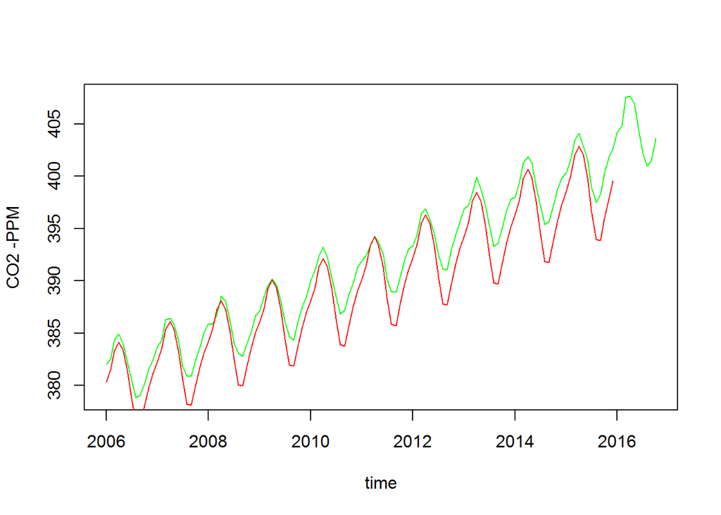

```r
plot(datas1.2006.new$datenew, 1/(datas1.2006.new$CO2.ppm.in)^0.5, xlab = 'time', ylab = 'CO2 -PPM', type='l',col='green')
lines(datas1.2006.new$datenew, 1/(pred.val.new)^0.5,col='red')
```

## Part 7

```r
No.of.mon.frm.2005 <- 12*(2020-2005) +575
December.2020 <- data.frame(time = No.of.mon.frm.2005, month = '12')

December.2020.CO2.ppm <- 1/(predict(reg3,newdata = December.2020))^0.5
December.2020.CO2.ppm
```

```
##        1
## 410.7643
```

The prediction for December 2020 is 410.76. This forecast might not be accurate due to the increasing error term in the model that needs to be addressed.